# Preparing the dataset for hippocampus segmentation

In this notebook you will use the skills and methods that we have talked about during our EDA Lesson to prepare the hippocampus dataset using Python. Follow the Notebook, writing snippets of code where directed so using Task comments, similar to the one below, which expects you to put the proper imports in place. Write your code directly in the cell with TASK comment. Feel free to add cells as you see fit, but please make sure that code that performs that tasked activity sits in the same cell as the Task comment.

```python
# TASK: Import the following libraries that we will use: nibabel, matplotlib, numpy
import numpy as np
import matplotlib.pyplot as plt
import nibabel as nib
import os
import random
from medpy.io import load as mload
```

```python
import torch
```

```python
import skimage
import skimage.transform
```

```python
%matplotlib inline
random.seed(21)
plt.rcParams["figure.figsize"] = (5,5)
```

It will help your understanding of the data a lot if you were able to use a tool that allows you to view NIFTI volumes, like [3D Slicer](https://www.slicer.org/). I will refer to Slicer throughout this Notebook and will be pasting some images showing what your output might look like.

## Loading NIFTI images using NiBabel

NiBabel is a python library for working with neuro-imaging formats (including NIFTI) that we have used in some of the exercises throughout the course. Our volumes and labels are in NIFTI format, so we will use nibabel to load and inspect them.

NiBabel documentation could be found here: https://nipy.org/nibabel/

Our dataset sits in two directories - *images* and *labels*. Each image is represented by a single file (we are fortunate to have our data converted to NIFTI) and has a corresponding label file which is named the same as the image file.

Note that our dataset is "dirty". There are a few images and labels that are not quite right. They should be quite obvious to notice, though. The dataset contains an equal amount of "correct" volumes and corresponding labels, and you don't need to alter values of any samples in order to get the clean dataset.

```python
# TASK: Your data sits in directory /data/TrainingSet.
# Load an image and a segmentation mask into variables called image and label
img_path = os.path.join(*['..', 'data', 'TrainingSet', 'images'])
lbl_path = os.path.join(*['..', 'data', 'TrainingSet', 'labels'])
```

```python
def get_nib2(path, fname):
    image, header = mload(os.path.join(path, fname))
    return image, header
```

```python
def diff_names(img_path, lbl_path):
    """
    return the differen names in two directory
    """
    img_names = set([_f  for _f in os.listdir(img_path)])
    lbl_names = set([_f for _f in os.listdir(lbl_path)])
    return (img_names | lbl_names) - (img_names & lbl_names)
```

```python
def get_nib(path, fname):
    """
    load the NIFTI file
    """
    return nib.load(os.path.join(path, fname))
```

```python
def diff_shape(fname):
    """
    return True if the image and label of fname got different shape else False
    """
    image_shape = get_nib(img_path, fname).header.get_data_shape()
    label_shape = get_nib(lbl_path, fname).header.get_data_shape()
    return image_shape != label_shape
```

```python
# find the files that do not exist in both img_path and label_path
all_files = set([_f  for _f in os.listdir(img_path)])
diff_name_files = diff_names(img_path, lbl_path)
```

```python
valid_files = all_files - diff_name_files
```

```python
diff_shape_files = set([_f for _f in valid_files if diff_shape(_f)])
```

```python
invalid_files = diff_shape_files | diff_name_files
invalid_files
```

```
{'hippocampus_010.nii.gz', 'hippocampus_118.nii.gz', 'hippocampus_281.nii.gz'}
```

```python
valid_files -= invalid_files
```

```python
file_names = list(valid_files)
```

```python
len(file_names)
```

```
260
```

```python
img = np.random.rand(40, 40)
```

```python
img
```

```
array([[0.17689881, 0.93669674, 0.1032484 , ..., 0.54978729, 0.00394971,
        0.55134664],
       [0.89306912, 0.14953622, 0.19294864, ..., 0.38372157, 0.53664076,
        0.8200111 ],
       [0.08257615, 0.72977511, 0.77330462, ..., 0.71835753, 0.08895838,
        0.71578005],
       ...,
       [0.26359878, 0.00572666, 0.35612681, ..., 0.91702454, 0.12530196,
        0.52035689],
       [0.77046187, 0.42275886, 0.54189691, ..., 0.20854277, 0.72102237,
        0.23632487],
       [0.387538  , 0.98249994, 0.4889428 , ..., 0.69923682, 0.4997108 ,
        0.97206913]])
```

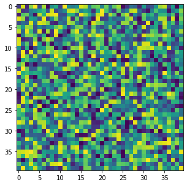

```python
plt.imshow(img)
```

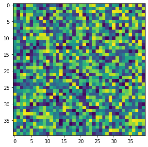

```python
plt.imshow(np.fliplr(img))
```

```python
img = plt.imread('image.jpg')
```

```python
img.shape
```

```
(960, 1280, 3)
```

[figure not shown]

```python
plt.imshow(img)
```

[figure not shown]

```python
plt.imshow(np.flipud(img))
```

```python
k  = np.flipud(img).copy()
```

```python
k
```

```
array([[[ 74,  51,  57],
        [ 67,  44,  50],
        [ 63,  42,  47],
        ...,
        [ 75,  39,  41],
        [ 73,  37,  41],
        [ 66,  29,  36]],

       [[ 72,  49,  55],
        [ 68,  45,  51],
        [ 65,  44,  49],
        ...,
        [ 73,  37,  39],
        [ 72,  36,  40],
        [ 66,  29,  36]],

       [[ 71,  48,  54],
        [ 69,  48,  53],
        [ 69,  48,  53],
        ...,
        [ 73,  34,  37],
        [ 72,  33,  38],
        [ 66,  27,  32]],

       ...,

       [[234, 127,  81],
        [235, 128,  82],
        [238, 131,  85],
        ...,
        [212,  91,  38],
        [212,  90,  39],
        [204,  82,  31]],

       [[240, 133,  87],
        [239, 132,  86],
        [238, 131,  85],
        ...,
        [210,  88,  37],
        [211,  89,  38],
        [206,  84,  33]],

       [[241, 134,  88],
        [238, 131,  85],
        [234, 127,  81],
        ...,
        [206,  84,  33],
        [209,  87,  36],
        [207,  85,  34]]], dtype=uint8)
```

```python
k3  = skimage.transform.rotate(k, angle = int(30))
```

[figure not shown]

```python
plt.imshow(k3)
```

```python
k2  = skimage.transform.rotate(k, angle = int(30), preserve_range = True)
```

```
Clipping input data to the valid range for imshow with RGB data ([0..1] for floats or [0..255] for integers).
```

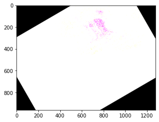

```python
plt.imshow(k2)
```

```python
angles = [-10, 10]
```

```python
random.randint(*angles)
```

```
-5
```

[figure not shown]

```python
plt.imshow(k)
```

[figure not shown]

```python
plt.imshow(np.fliplr(img))
```

[figure not shown]

```python
plt.imshow(skimage.util.random_noise(img, mode = 'salt'))
```

```python
img2 = (img - img.min()) / (img.max() - img.min())
```

[figure not shown]

```python
plt.imshow(img2)
```

```python
img2.min(), img2.max()
```

```
(0.0, 1.0)
```

```python
img3 = skimage.util.random_noise(img2, mode = 's&p', amount = 0.3)
```

[figure not shown]

```python
plt.imshow(img3)
```

```python
noises = np.arange(0, 11)/100
```

```python
random.choice(noises)
```

```
0.06
```

```python
img4 = skimage.util.random_noise(img2, mean = -1)
```

```python
img4.min(), img4.max()
```

```
(0.0, 0.42731483503331513)
```

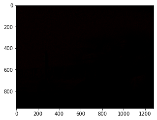

```python
plt.imshow(img4)
```

```python
# Nibabel can present your image data as a Numpy array by calling the method get_fdata()
# The array will contain a multi-dimensional Numpy array with numerical values representing voxel intensities.
# In our case, images and labels are 3-dimensional, so get_fdata will return a 3-dimensional array. You can verify this
# by accessing the .shape attribute. What are the dimensions of the input arrays?

# TASK: using matplotlib, visualize a few slices from the dataset, along with their labels.
# You can adjust plot sizes like so if you find them too small:
# plt.rcParams["figure.figsize"] = (10,10)
```

```python
# take 3 samples from valid file_names, visualize the slices of them
sample_fnames = random.sample(file_names, 3)
sample_fnames
```

```
['hippocampus_279.nii.gz', 'hippocampus_225.nii.gz', 'hippocampus_148.nii.gz']
```

```python
t_image, t_header = get_nib2(img_path, sample_fnames[0])
```

```python
t_image.shape
```

```
(34, 50, 32)
```

```python
t_image.ptp()
```

```
1374.974
```

```python
random.randint(-20, 20)
```

```
-7
```

```python
t_image.max(), t_image.min()
```

```
(1374.974, 0.0)
```

```python
norm_t_image = (t_image - t_image.min())/(t_image.max() - t_image.min())
```

```python
norm_t_image.min(), norm_t_image.max()
```

```
(0.0, 1.0)
```

```python
norm_t_image.mean(), norm_t_image.std()
```

```
(0.28637156, 0.13179554)
```

```python
t_label, t_label_header = get_nib2(lbl_path, sample_fnames[0])
```

```python
shapes = [get_nib(img_path, _f).header.get_data_shape() for _f in file_names]
```

```python
x = [s[0] for s in shapes]
y = [s[1] for s in shapes]
z = [s[2] for s in shapes]
print(min(x), max(x))
print(min(y), max(y))
print(min(z), max(z))
```

```
31 43
40 59
24 47
```

```python
t_zero = np.zeros([3, 3, 3])
```

```python
t_zero
```

```
array([[[0., 0., 0.],
        [0., 0., 0.],
        [0., 0., 0.]],

       [[0., 0., 0.],
        [0., 0., 0.],
        [0., 0., 0.]],

       [[0., 0., 0.],
        [0., 0., 0.],
        [0., 0., 0.]]])
```

```python
t_one = np.ones([3, 4, 4])
```

```python
t_zero2 = np.zeros([3, 4, 4])
```

```python
t_one
```

```
array([[[1., 1., 1., 1.],
        [1., 1., 1., 1.],
        [1., 1., 1., 1.],
        [1., 1., 1., 1.]],

       [[1., 1., 1., 1.],
        [1., 1., 1., 1.],
        [1., 1., 1., 1.],
        [1., 1., 1., 1.]],

       [[1., 1., 1., 1.],
        [1., 1., 1., 1.],
        [1., 1., 1., 1.],
        [1., 1., 1., 1.]]])
```

```python
t_one.sum()
```

```
48.0
```

```python
t_zero2[0, :, :] = 2
```

```python
t_zero2
```

```
array([[[2., 2., 2., 2.],
        [2., 2., 2., 2.],
        [2., 2., 2., 2.],
        [2., 2., 2., 2.]],

       [[0., 0., 0., 0.],
        [0., 0., 0., 0.],
        [0., 0., 0., 0.],
        [0., 0., 0., 0.]],

       [[0., 0., 0., 0.],
        [0., 0., 0., 0.],
        [0., 0., 0., 0.],
        [0., 0., 0., 0.]]])
```

```python
torch_test = torch.from_numpy(t_zero2).type(torch.float)
```

```python
torch_test.shape
```

```
torch.Size([3, 4, 4])
```

```python
torch_test = torch_test.unsqueeze(0)
torch_test
```

```
tensor([[[[2., 2., 2., 2.],
          [2., 2., 2., 2.],
          [2., 2., 2., 2.],
          [2., 2., 2., 2.]],

         [[0., 0., 0., 0.],
          [0., 0., 0., 0.],
          [0., 0., 0., 0.],
          [0., 0., 0., 0.]],

         [[0., 0., 0., 0.],
          [0., 0., 0., 0.],
          [0., 0., 0., 0.],
          [0., 0., 0., 0.]]]])
```

```python
torch_test.cpu().detach()
```

```
tensor([[[[2., 2., 2., 2.],
          [2., 2., 2., 2.],
          [2., 2., 2., 2.],
          [2., 2., 2., 2.]],

         [[0., 0., 0., 0.],
          [0., 0., 0., 0.],
          [0., 0., 0., 0.],
          [0., 0., 0., 0.]],

         [[0., 0., 0., 0.],
          [0., 0., 0., 0.],
          [0., 0., 0., 0.],
          [0., 0., 0., 0.]]]])
```

```python
t2 = torch_test.squeeze()
```

```python
t2.shape
```

```
torch.Size([3, 4, 4])
```

```python
(t_zero2 > 0).sum()
```

```
16
```

```python
(t_one * t_zero2).sum()
```

```
32.0
```

```python
t_one
```

```
array([[[1., 1., 1., 1.],
        [1., 1., 1., 1.],
        [1., 1., 1., 1.],
        [1., 1., 1., 1.]],

       [[1., 1., 1., 1.],
        [1., 1., 1., 1.],
        [1., 1., 1., 1.],
        [1., 1., 1., 1.]],

       [[1., 1., 1., 1.],
        [1., 1., 1., 1.],
        [1., 1., 1., 1.],
        [1., 1., 1., 1.]]])
```

```python
x1, y1, z1 = t_one.shape
x2, y2, z2 = t_zero.shape
```

```python
x1, y1, z1
```

```
(3, 4, 4)
```

```python
x2, y2, z2
```

```
(3, 3, 3)
```

```python
for i in range(3):
    t_zero[i, :, :] = t_one[i, :3, :3]
```

```python
assert x1 >= x2 and y1 > y2 and z1 > z2
```

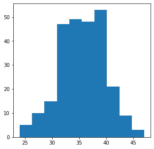

```python
plt.hist(z)
```

```python
patch_size = 64
y_shape = patch_size
z_shape = patch_size
```

```python
def med_reshape(image, new_shape):
    """
    This function reshapes 3D data to new dimension padding with zeros
    and leaving the content in the top-left corner

    Arguments:
        image {array} -- 3D array of pixel data
        new_shape {3-tuple} -- expected output shape

    Returns:
        3D array of desired shape, padded with zeroes
    """

    reshaped_image = np.zeros(new_shape)

    # TASK: write your original image into the reshaped image
    # <CODE GOES HERE>
    reshaped_image[:,0,0] = image[:,0,0]

    return reshaped_image
```

```python
r_image = med_reshape(norm_t_image, new_shape=(norm_t_image.shape[0], y_shape, z_shape))
r_label = med_reshape(t_label, new_shape=(t_label.shape[0], y_shape, z_shape)).astype(int)
# r_label = med_reshape(t_label, new_shape=(t_label.shape[0], y_shape, z_shape))
```

```python
r_image.sum()
```

```
7.687747322022915
```

```python
r_label.sum()
```

```
0
```

```python
np.zeros(1)
```

```
array([0.])
```

```python
keys = list(range(len(file_names)))
```

```python
random.shuffle(keys)
```

```python
print(keys)
```

```
[178, 182, 135, 196, 136, 181, 69, 144, 206, 15, 64, 190, 77, 30, 13, 79, 244, 119, 57, 80, 162, 45, 52, 150, 73, 165, 222, 134, 219, 91, 71, 49, 58, 229, 42, 171, 161, 72, 211, 2, 101, 65, 24, 147, 11, 242, 188, 14, 156, 25, 20, 34, 227, 245, 163, 90, 201, 55, 118, 191, 66, 160, 92, 167, 174, 100, …
```

```python
split = dict()
train_weights = [0.8, 0.1, 0.1]
train_len, val_len, test_len = [int(_r * len(file_names)) for _r in train_weights]
```

```python
train_len, val_len, test_len
```

```
(208, 26, 26)
```

```python
indices = list(range(len(file_names)))
random.shuffle(indices)
```

```python
split['train'] = indices[:train_len]
split['val'] = indices[train_len: train_len + val_len]
split['test'] = indices[train_len + val_len:]
```

```python
split
```

[output not shown]

[output cut: 205 more lines]

[output not shown]

```python
def view_slice_image(fname):
    """
    view 3 cardinal planes of image and its lable
    """
    image = get_nib(img_path, fname).get_fdata()
    label = get_nib(lbl_path, fname).get_fdata()
    assert image.shape == label.shape
    print(f'The shape of {fname} is {image.shape}')
    fig, ax = plt.subplots(3, 2, figsize = [10, 10])
    x, y, z = image.shape
    ax[0, 0].imshow(image[x // 2, :, :], cmap = 'gray')
    ax[0, 1].imshow(label[x // 2, :, :], cmap = 'gray')
    ax[1, 0].imshow(image[:, y // 2, :], cmap = 'gray')
    ax[1, 1].imshow(label[:, y // 2, :], cmap = 'gray')
    ax[2, 0].imshow(image[:, :, z// 2], cmap = 'gray')
    ax[2, 1].imshow(label[:, :, z// 2], cmap = 'gray')
    plt.show()
```

```
The shape of hippocampus_279.nii.gz is (34, 50, 32)
```

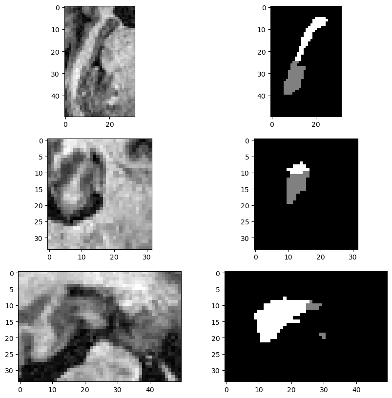

```
The shape of hippocampus_225.nii.gz is (33, 53, 26)
```

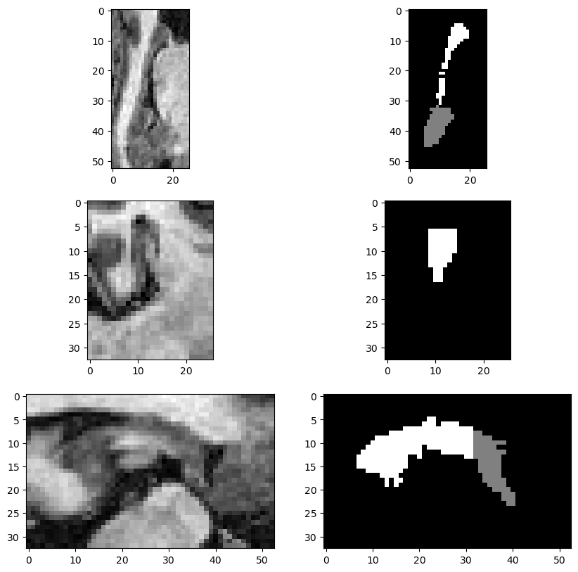

```
The shape of hippocampus_148.nii.gz is (34, 48, 32)
```

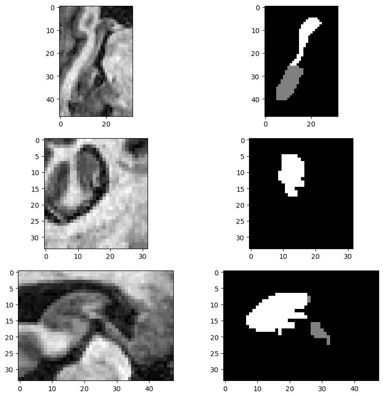

```python
plt.style.use('default')
for _f in sample_fnames:
    view_slice_image(_f)
```

Load volume into 3D Slicer to validate that your visualization is correct and get a feel for the shape of structures.Try to get a visualization like the one below (hint: while Slicer documentation is not particularly great, there are plenty of YouTube videos available! Just look it up on YouTube if you are not sure how to do something)

[figure not shown]

```python
# Stand out suggestion: use one of the simple Volume Rendering algorithms that we've
# implemented in one of our earlier lessons to visualize some of these volumes
```

## Looking at single image data

In this section we will look closer at the NIFTI representation of our volumes. In order to measure the physical volume of hippocampi, we need to understand the relationship between the sizes of our voxels and the physical world.

```python
# Nibabel supports many imaging formats, NIFTI being just one of them. I told you that our images
# are in NIFTI, but you should confirm if this is indeed the format that we are dealing with
# TASK: using .header_class attribute - what is the format of our images?
```

```python
img_format = set([get_nib(img_path, _f).header_class for _f in file_names])
lbl_format = set([get_nib(lbl_path, _f).header_class for _f in file_names])
```

```python
img_format, lbl_format
```

```
({nibabel.nifti1.Nifti1Header}, {nibabel.nifti1.Nifti1Header})
```

The format of our images is nifti1

Further down we will be inspecting .header attribute that provides access to NIFTI metadata. You can use this resource as a reference for various fields: https://brainder.org/2012/09/23/the-nifti-file-format/

```python
image = get_nib(img_path, sample_fnames[0])
label = get_nib(lbl_path, sample_fnames[0])
```

```python
image_header = dict(image.header)
```

```python
image_header
```

```
{'sizeof_hdr': array(348),
 'data_type': array(b'', dtype='|S10'),
 'db_name': array(b'', dtype='|S18'),
 'extents': array(0),
 'session_error': array(0, dtype=int16),
 'regular': array(b'r', dtype='|S1'),
 'dim_info': array(0, dtype=uint8),
 'dim': array([ 3, 34, 50, 32,  1,  1,  1,  1], dtype=int16),
 'intent_p1': array(0., dtype=float32),
 'intent_p2': array(0., dtype=float32),
 'intent_p3': array(0., dtype=float32),
 'intent_code': array(0, dtype=int16),
 'datatype': array(16, dtype=int16),
 'bitpix': array(32, dtype=int16),
 'slice_start': array(0, dtype=int16),
 'pixdim': array([1., 1., 1., 1., 1., 0., 0., 0.], dtype=float32),
 'vox_offset': array(0., dtype=float32),
 'scl_slope': array(nan, dtype=float32),
 'scl_inter': array(nan, dtype=float32),
 'slice_end': array(0, dtype=int16),
 'slice_code': array(0, dtype=uint8),
 'xyzt_units': array(10, dtype=uint8),
 'cal_max': array(0., dtype=float32),
 'cal_min': array(0., dtype=float32),
 'slice_duration': array(0., dtype=float32),
 'toffset': array(0., dtype=float32),
 'glmax': array(0),
 'glmin': array(0),
 'descrip': array(b'5.0.10', dtype='|S80'),
 'aux_file': array(b'none', dtype='|S24'),
 'qform_code': array(1, dtype=int16),
 'sform_code': array(1, dtype=int16),
 'quatern_b': array(0., dtype=float32),
 'quatern_c': array(0., dtype=float32),
 'quatern_d': array(0., dtype=float32),
 'qoffset_x': array(1., dtype=float32),
 'qoffset_y': array(1., dtype=float32),
 'qoffset_z': array(1., dtype=float32),
 'srow_x': array([1., 0., 0., 1.], dtype=float32),
 'srow_y': array([0., 1., 0., 1.], dtype=float32),
 'srow_z': array([0., 0., 1., 1.], dtype=float32),
 'intent_name': array(b'', dtype='|S16'),
 'magic': array(b'n+1', dtype='|S4')}
```

```python
# TASK: How many bits per pixel are used?
# bitpix: Number of bits per voxel.
print('{} bits per voxel'.format(image_header['bitpix']))
```

```
32 bits per voxel
```

```python
# TASK: What are the units of measurement?
# voxel sizes in milimeters
print('Voxel sizes in 3 dimensions are (mm): {}  {} {}'.format(*image.header.get_zooms()))
```

```
Voxel sizes in 3 dimensions are (mm): 1.0  1.0 1.0
```

```python
# TASK: Do we have a regular grid? What are grid spacings?
image_header['pixdim'] # Grid spacings (unit per dimension)
```

```
array([1., 1., 1., 1., 1., 0., 0., 0.], dtype=float32)
```

Yes, it is a regular grid

```python
image_header['xyzt_units']
```

```
array(10, dtype=uint8)
```

Grid spacing is 1mm

```python
# TASK: What dimensions represent axial, sagittal, and coronal slices? How do you know?
print(image_header['dim'])
print('Sagittal:', image_header['dim'][1])
print('Coronal:', image_header['dim'][2])
print('Axial:', image_header['dim'][3])
```

```
[ 3 34 50 32  1  1  1  1]
Sagittal: 34
Coronal: 50
Axial: 32
```

```python
# By now you should have enough information to decide what are dimensions of a single voxel
# TASK: Compute the volume (in mm³) of a hippocampus using one of the labels you've loaded.
# You should get a number between ~2200 and ~4500
```

```python
def calc_volume(fname, voxel_size):
    """
    calculate the volume of a label, if the voxel size in 3 dimension is same
    """
    label = get_nib(lbl_path, fname).get_fdata()
    return sum(1 for i in label.flatten() if i > 0) * voxel_size
```

```python
[calc_volume(_f, 1) for _f in sample_fnames]
```

```
[2382, 2475, 2945]
```

```python
test_label = get_nib(lbl_path, sample_fnames[0]).get_fdata()
```

```python
np.sum(test_label == 2)
```

```
1121
```

```python
np.sum(test_label == 1)
```

```
1261
```

```python
test_label.shape
```

```
(34, 50, 32)
```

```python
len(test_label.flatten())
```

```
54400
```

```python
np.sum(test_label >= 0)
```

```
54400
```

```python
np.sum(test_label.flatten() == 1)
```

```
1261
```

```python
calc_volume(sample_fnames[0], 1)
```

```
2382
```

## Plotting some charts

```python
# TASK: Plot a histogram of all volumes that we have in our dataset and see how
# our dataset measures against a slice of a normal population represented by the chart below.
volumes = [calc_volume(_f, 1) for _f in valid_files]
```

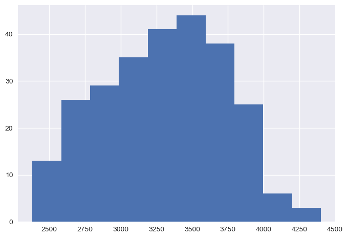

```python
plt.style.use('seaborn')
plt.hist(volumes, bins = 'auto')
```

[figure not shown]

Do you see any outliers? Why do you think it's so (might be not immediately obvious, but it's always a good idea to inspect) outliers closer. If you haven't found the images that do not belong, the histogram may help you.

In the real world we would have precise information about the ages and conditions of our patients, and understanding how our dataset measures against population norm would be the integral part of clinical validation that we talked about in last lesson. Unfortunately, we do not have this information about this dataset, so we can only guess why it measures the way it is. If you would like to explore further, you can use the [calculator from HippoFit project](http://www.smanohar.com/biobank/calculator.html) to see how our dataset compares against different population slices

Did you notice anything odd about the label files? We hope you did! The mask seems to have two classes, labeled with values `1` and `2` respectively. If you visualized sagittal or axial views, you might have gotten a good guess of what those are. Class 1 is the anterior segment of the hippocampus and class 2 is the posterior one.

For the purpose of volume calculation we do not care about the distinction, however we will still train our network to differentiate between these two classes and the background

```python
# TASK: Copy the clean dataset to the output folder inside section1/out. You will use it in the next Section
if os.name == 'nt':
    copy = 'copy'
else:
    copy = 'cp'
source_path = ['..', 'data', 'TrainingSet']
dest_path = ['.', 'out']
dest_img_path = os.path.join(*dest_path, 'images')
dest_lbl_path = os.path.join(*dest_path, 'labels')
source_img_path = os.path.join(*source_path, 'images')
source_lbl_path = os.path.join(*source_path, 'labels')
if 'images' not in os.listdir(os.path.join(*dest_path)):
    os.mkdir(dest_img_path)
if 'labels' not in os.listdir(os.path.join(*dest_path)):
    os.mkdir(dest_lbl_path)
for _f in file_names:
    os.popen('{} {} {}'.format(copy, os.path.join(source_img_path, _f), os.path.join(dest_img_path, _f)))
    os.popen('{} {} {}'.format(copy, os.path.join(source_lbl_path, _f), os.path.join(dest_lbl_path, _f)))
```

[output not shown]

## Final remarks

Congratulations! You have finished Section 1.

In the next section you will create training and testing pipelines for a UNet-based machine learning model, run and monitor the execution, and will produce test metrics. This will arm you with all you need to use the model in the clinical context and reason about its performance!